# Racism and its Roots: Mass Incarceration

Sarah Haworth

2022-11-21

## Abstract

This report creates multiple charts that examine the total jail population in the US based off a variety of factors including race, year, state, and urbanicity. The data is sourced from *Vera Institute of Justice*. It answers questions about how mass incarceration has a much greater impact on marginalized groups compared to white people.

## Introduction

Mass incarceration has grown exponentially in the U.S. from 1970 to 2000 thanks to elected officials and policymakers. These people in power have been making deliberate decisions that led to the rise of the prison population. These decisions have targeted the incarceration of people of color, immigrants, and people experiencing poverty. Black people specifically have been subject to over policing and over-arrest for low-level behavior. According to the *Vera Institute of Justice*, black men comprise about 13% of the total male population in the U.S., but 35% of the incarcerated population.

If incarceration actually made society a safer place, the United States would be the safest nation in the world. So why does mass incarceration exist? To reinforce the racism rooted in the United States. In 1865, when the 13th Amendment was passed and the Civil War was coming to an end, the first prison boom involving the incarceration of a disproportionate number of black people was triggered. Later, in 1970, politicians were making decisions to hinder the Civil Rights Movement and link crime with race. Speeches and comments were tainted with explicit racial undertones. This type of conduct by politicians is what fostered the rise of mass incarceration.

The data set explored in this report will help to understand the difference between the total population, the population of white people in jail, and the population of different marginalized groups in jail. It allows researchers to analyze the trends between groups based on a few different factors including age, sex (M/F), and location. The direct stakeholders that are impacted by this research include the marginalized groups of society, who can clearly see how the decisions of politicians have affected their lives, and white people, who don’t understand the privilege that they possess due to the color of their skin.

## Data Summary

1993 was the year where the black jail population was at its highest.

The state with the highest number of black people in jail is California. This doesn’t convey many trends because the state with the highest number of people in jail, and the state with the largest total population is also California.

The state with the highest rate of black people in jail is Utah. It is interesting to note that the state with the highest rate of white people in jail is Louisiana.

## Growth of the U.S. Prison Population

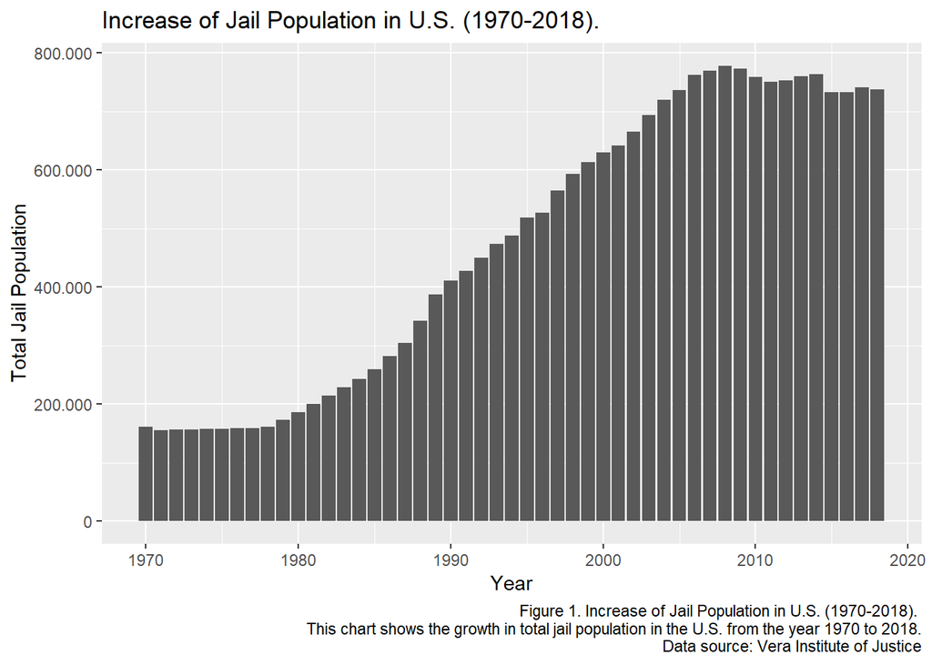

```r
plot_jail_pop_for_us()
```

## Growth of Prison Population by State

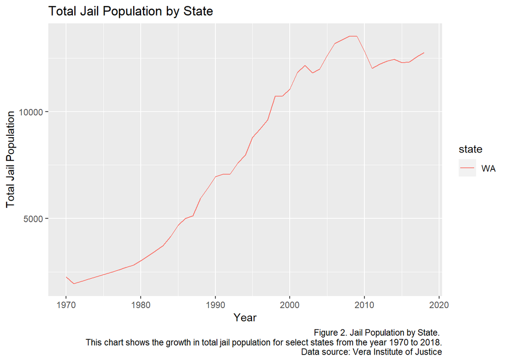

```r
plot_jail_pop_by_states("WA")
```

## Exploring the Urbanicity of Prison Populations

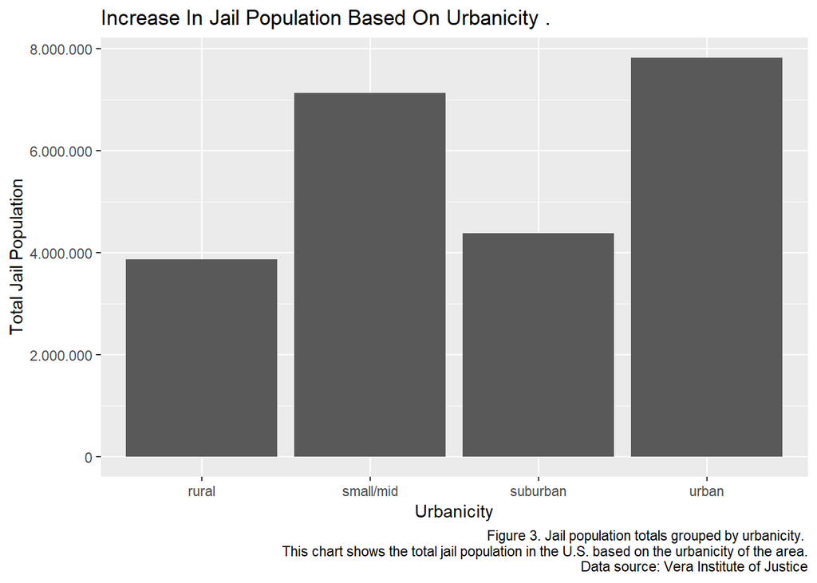

```r
bar_graph_by_urbanciity()
```

Is urbanicity related to total jail population? Urban areas have the greatest jail population, closely followed by small/mid areas. Rural areas have the smallest jail population, but suburban areas only have a larger population by a few 100,000.

## How the Jail Population Differed by State in 2018.

[figure not shown]

```r
jail_pop_map()
```